# Kiem tra lan 2 - KDL 1

Nguyen Thanh Duy

2026-06-04

### Bai tap Nhom 1: Tien xu ly du lieu va Kham pha phan phoi

#### 1. Khoi tao va lam sach du lieu

Du lieu ban dau gom 5000 thoi gian lam bai. Sau khi chen loi `NA` va gia tri am, nhom loc lai nhung quan sat hop le va luu vao `final_data`.

```r
set.seed(104)

raw_time <- rnorm(5000, mean = 60, sd = 15)

na_pos <- sample(seq_along(raw_time), 150)
raw_time[na_pos] <- NA

negative_pool <- setdiff(seq_along(raw_time), na_pos)
negative_pos <- sample(negative_pool, 50)
raw_time[negative_pos] <- -abs(raw_time[negative_pos])

clean_time <- raw_time[!is.na(raw_time) & raw_time >= 0]
final_data <- data.frame(Time = clean_time)
final_data_time <- final_data

c(
  so_quan_sat_ban_dau = length(raw_time),
  so_NA = sum(is.na(raw_time)),
  so_gia_tri_am = sum(raw_time < 0, na.rm = TRUE),
  so_quan_sat_sau_lam_sach = nrow(final_data)
)
```

```
##      so_quan_sat_ban_dau                    so_NA            so_gia_tri_am
##                     5000                      150                       51
## so_quan_sat_sau_lam_sach
##                     4799
```

```r
head(final_data)
```

```
##       Time
## 1 69.41454
## 2 69.65675
## 3 55.31165
## 4 75.86822
## 5 64.80311
## 6 59.08909
```

#### 2. Kham pha phan phoi

```r
mean_time <- mean(final_data$Time)
sd_time <- sd(final_data$Time)

c(trung_binh_mau = mean_time, do_lech_chuan_mau = sd_time)
```

```
##    trung_binh_mau do_lech_chuan_mau
##          60.18405          14.88198
```

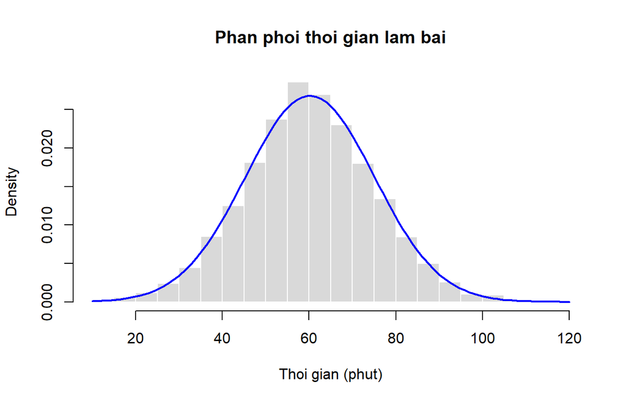

```r
hist(final_data$Time,
     freq = FALSE,
     breaks = 30,
     col = "gray85",
     border = "white",
     main = "Phan phoi thoi gian lam bai",
     xlab = "Thoi gian (phut)")

curve(dnorm(x, mean = mean_time, sd = sd_time),
      add = TRUE,
      col = "blue",
      lwd = 2)
```

Histogram co dang gan voi duong mat do chuan vi du lieu duoc sinh tu phan phoi chuan va cac loi da duoc loai bo.

#### 3. Xac suat hoan thanh som hon 45 phut

```r
prob_before_45 <- pnorm(45, mean = mean_time, sd = sd_time)
prob_before_45
```

```
## [1] 0.1537937
```

Xac suat uoc tinh mot sinh vien hoan thanh bai thi som hon 45 phut la 0.1538.

#### 4. Moc thoi gian cho top 5% nop bai nhanh nhat

```r
fastest_5_percent_cutoff <- qnorm(0.05, mean = mean_time, sd = sd_time)
fastest_5_percent_cutoff
```

```
## [1] 35.70537
```

Theo mo hinh chuan tu mau, sinh vien can hoan thanh khong qua 35.71 phut de nam trong nhom 5% nhanh nhat.

### Bai tap Nhom 2: Mo phong CLT va khoang tin cay phuong sai

#### 1. Viet ham mo phong

Ham `simulate_clt_exp()` rut mau tu phan phoi mu, tinh trung binh mau, va lap lai qua `R` lan.

```r
simulate_clt_exp <- function(n, lambda, R = 5000) {
  sample_means <- numeric(R)

  for (i in seq_len(R)) {
    sample_means[i] <- mean(rexp(n, rate = lambda))
  }

  sample_means
}

set.seed(202)

n_exp <- 40
lambda_exp <- 0.2
exp_means <- simulate_clt_exp(n = n_exp, lambda = lambda_exp, R = 5000)

head(exp_means)
```

```
## [1] 5.397524 4.905780 6.038972 5.454349 4.857002 4.137833
```

#### 2. Kiem chung hoi tu CLT

Voi phan phoi mu co tham so `lambda`, trung binh tong the la `1 / lambda`. Phuong sai cua trung binh mau kich thuoc `n` la `1 / (n * lambda^2)`.

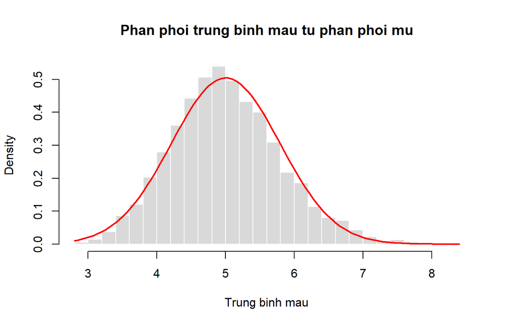

```r
theory_mean <- 1 / lambda_exp
theory_sd <- sqrt(1 / (n_exp * lambda_exp^2))

hist(exp_means,
     freq = FALSE,
     breaks = 35,
     col = "gray85",
     border = "white",
     main = "Phan phoi trung binh mau tu phan phoi mu",
     xlab = "Trung binh mau")

curve(dnorm(x, mean = theory_mean, sd = theory_sd),
      add = TRUE,
      col = "red",
      lwd = 2)
```

```r
c(trung_binh_ly_thuyet = theory_mean, do_lech_chuan_ly_thuyet = theory_sd)
```

```
##    trung_binh_ly_thuyet do_lech_chuan_ly_thuyet
##               5.0000000               0.7905694
```

Duong chuan ly thuyet bam sat histogram cua cac trung binh mau, phu hop voi Dinh ly Gioi han Trung tam.

#### 3. Khoang tin cay 95% cho phuong sai

```r
set.seed(203)

sample_30 <- sample(exp_means, size = 30)
sample_var <- var(sample_30)
df_var <- length(sample_30) - 1
alpha_var <- 0.05

var_ci <- c(
  lower = df_var * sample_var / qchisq(1 - alpha_var / 2, df = df_var),
  upper = df_var * sample_var / qchisq(alpha_var / 2, df = df_var)
)

variance_report <- data.frame(
  sample_variance = sample_var,
  lower_95 = var_ci["lower"],
  upper_95 = var_ci["upper"]
)

variance_report
```

```
##       sample_variance lower_95  upper_95
## lower       0.3701377 0.234765 0.6689067
```

#### 4. Truc quan hoa khoang tin cay

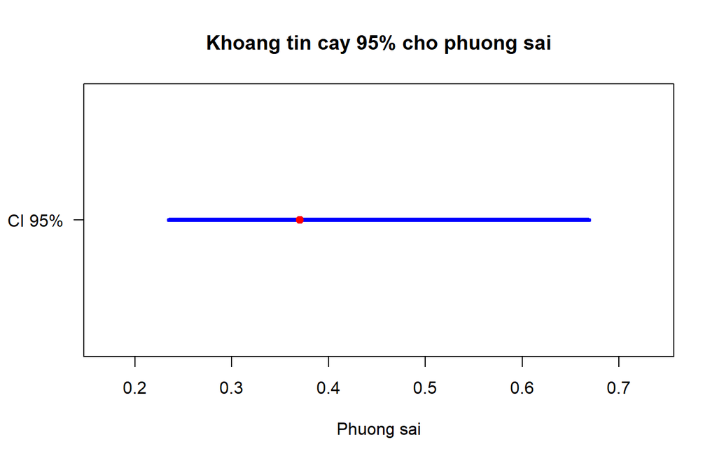

```r
pad_var <- diff(var_ci) * 0.15

plot(NA,
     xlim = c(var_ci["lower"] - pad_var, var_ci["upper"] + pad_var),
     ylim = c(0, 1),
     yaxt = "n",
     xlab = "Phuong sai",
     ylab = "",
     main = "Khoang tin cay 95% cho phuong sai")

segments(var_ci["lower"], 0.5, var_ci["upper"], 0.5,
         col = "blue", lwd = 4)
points(sample_var, 0.5, pch = 19, col = "red")
axis(2, at = 0.5, labels = "CI 95%", las = 1)
```

Diem mau do la phuong sai mau, con doan mau xanh la khoang tin cay 95% cho phuong sai.

### Bai tap Nhom 3: Uoc luong MoM, MLE va khoang tin cay phi tham so

#### 1. Khoi tao du lieu an

Trong phan nay, `final_data` duoc tao lai theo dung yeu cau cua bai tap Beta.

```r
set.seed(303)

final_data <- data.frame(
  ram_usage = rbeta(3000, shape1 = 2, shape2 = 5)
)

ram_usage <- final_data$ram_usage

summary(ram_usage)
```

```
##     Min.  1st Qu.   Median     Mean  3rd Qu.     Max.
## 0.001986 0.165156 0.270482 0.287036 0.388240 0.813472
```

#### 2. Uoc luong MoM

Voi phan phoi Beta, dat `m` la trung binh mau va `v` la phuong sai mau:

$$\hat{\alpha} = m \left(\frac{m(1-m)}{v} - 1\right), \qquad
\hat{\beta} = (1-m) \left(\frac{m(1-m)}{v} - 1\right)$$

```r
m_ram <- mean(ram_usage)
v_ram <- var(ram_usage)
common_part <- m_ram * (1 - m_ram) / v_ram - 1

alpha_mom <- m_ram * common_part
beta_mom <- (1 - m_ram) * common_part

mom_result <- c(alpha_MoM = alpha_mom, beta_MoM = beta_mom)
mom_result
```

```
## alpha_MoM  beta_MoM
##  2.103601  5.225100
```

#### 3. Uoc luong MLE

```r
nll_beta <- function(params, data) {
  alpha <- params[1]
  beta <- params[2]
  -sum(dbeta(data, shape1 = alpha, shape2 = beta, log = TRUE))
}

mle_fit <- nlminb(
  start = c(alpha_mom, beta_mom),
  objective = nll_beta,
  data = ram_usage,
  lower = c(1e-6, 1e-6)
)

alpha_mle <- mle_fit$par[1]
beta_mle <- mle_fit$par[2]

mle_result <- c(alpha_MLE = alpha_mle, beta_MLE = beta_mle)
mle_result
```

```
## alpha_MLE  beta_MLE
##  2.064937  5.146358
```

Gia tri MLE gan voi tham so sinh du lieu ban dau, nen qua trinh toi uu hoa dang cho ket qua hop ly.

#### 4. So sanh truc quan MoM va MLE

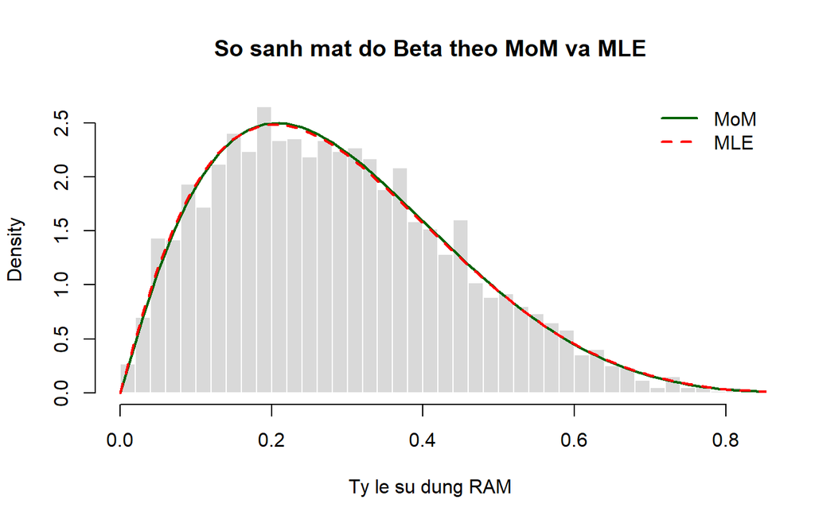

```r
hist(ram_usage,
     freq = FALSE,
     breaks = 40,
     col = "gray85",
     border = "white",
     main = "So sanh mat do Beta theo MoM va MLE",
     xlab = "Ty le su dung RAM")

curve(dbeta(x, shape1 = alpha_mom, shape2 = beta_mom),
      from = 0, to = 1,
      add = TRUE,
      col = "darkgreen",
      lwd = 2)

curve(dbeta(x, shape1 = alpha_mle, shape2 = beta_mle),
      from = 0, to = 1,
      add = TRUE,
      col = "red",
      lwd = 2,
      lty = 2)

legend("topright",
       legend = c("MoM", "MLE"),
       col = c("darkgreen", "red"),
       lty = c(1, 2),
       lwd = 2,
       bty = "n")
```

Hai duong uoc luong gan nhau va deu nam sat phan phoi thuc te cua `ram_usage`.

#### 5. Khoang tin cay phi tham so 99% cho trung vi

Khoang tin cay duoc lay tu thong ke thu tu. Chi so can duoi va can tren duoc tinh bang `qbinom()` voi xac suat 0.5 vi xet trung vi.

```r
ordered_ram <- sort(ram_usage)
n_ram <- length(ordered_ram)
alpha_median <- 0.01

lower_index <- qbinom(alpha_median / 2, size = n_ram, prob = 0.5)
upper_index <- qbinom(1 - alpha_median / 2, size = n_ram, prob = 0.5) + 1

lower_index <- max(1, lower_index)
upper_index <- min(n_ram, upper_index)

median_ci <- c(
  lower = ordered_ram[lower_index],
  upper = ordered_ram[upper_index]
)

coverage <- pbinom(upper_index - 1, size = n_ram, prob = 0.5) -
  pbinom(lower_index - 1, size = n_ram, prob = 0.5)

median_report <- data.frame(
  lower_index = lower_index,
  upper_index = upper_index,
  lower_99 = median_ci["lower"],
  upper_99 = median_ci["upper"],
  coverage = coverage
)

median_report
```

```
##       lower_index upper_index  lower_99  upper_99  coverage
## lower        1429        1572 0.2607846 0.2809911 0.9909784
```

Khoang tin cay 99% cho trung vi cua `ram_usage` la tu 0.2608 den 0.281.